# Situational report on the Ebola Virus Disease (EVD) outbreak in southwest Uganda

Roxanne Beauclair and Ivy Kombe

2020-02-13

# **Situation Update**

This report contains information about the baseline EVD situation in Uganda. The results from this report are based upon the best information that is currently available. As more data is collected, the report will be updated. Over a period of five months, from 05 Sep, 2019 to 31 Jan, 2020, there have been 111 reported cases of EVD from a community of 400 people. Of the 111 reported cases, 72 were confirmed, 35 were probable, and 4 suspected.

The following figures show the weekly incidence over the 2019 calendar year. The incidence is presented by both case definition and the gender of the case. The different case types are definied in the following way, according to the WHO Ebola Response Team (2014): “A suspected case is illness in any person, alive or dead, who has (or had) sudden onset of high fever and had contact with a person with a suspected, probable, or confirmed Ebola case or with a dead or sick animal; any person with sudden onset of high fever and at least three of the following symptoms: headache, vomiting, anorexia or loss of appetite, diarrhea, lethargy, stomach pain, aching muscles or joints, difficulty swallowing, breathing difficulties, or hiccupping; or any person who had unexplained bleeding or who died suddenly from an unexplained cause. A probable case is illness in any person suspected to have EVD who was evaluated by a clinician or any person who died from suspected Ebola and had an epidemiologic link to a person with a confirmed case but was not tested and did not have laboratory confirmation of the disease. A probable or suspected case was classified as confirmed when a sample from the person was positive for Ebola virus in laboratory testing.” (p. 1486)

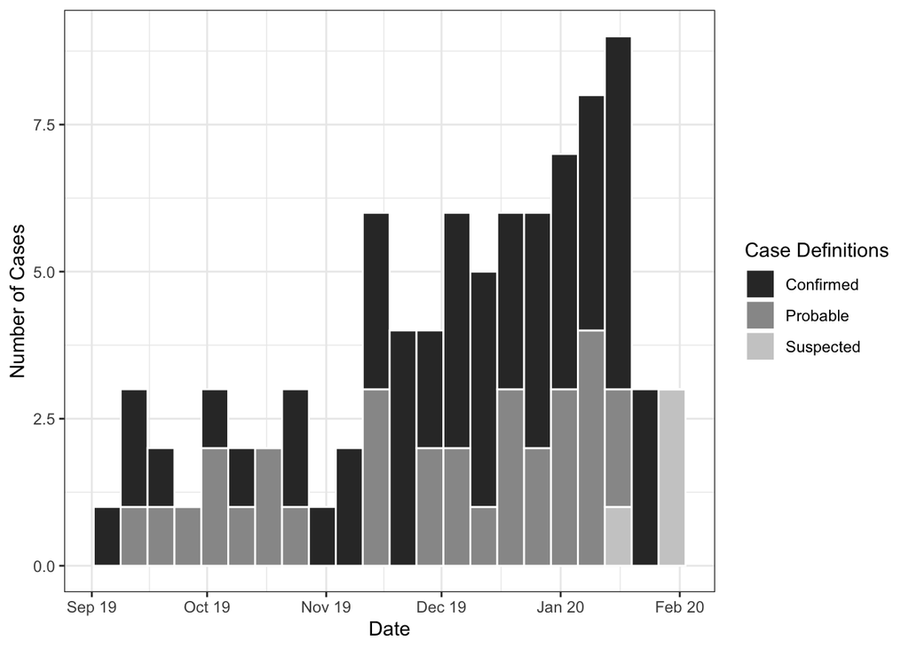

**Figure 1: Weekly incidence by case definition**

Overall, in the first two months of the epidemic case counts remained under four per week (Figure 1). From November, there was a marked increase in the number of new cases, with case counts peaking in mid-January. Thereafter, the number of cases fell to only three per week. The vast majority of cases are probable or confirmed. In the most recent weeks, there were a few suspected cases because there has not been an opportunity for physicians to provide clinical diagnoses or lab confirmation yet.

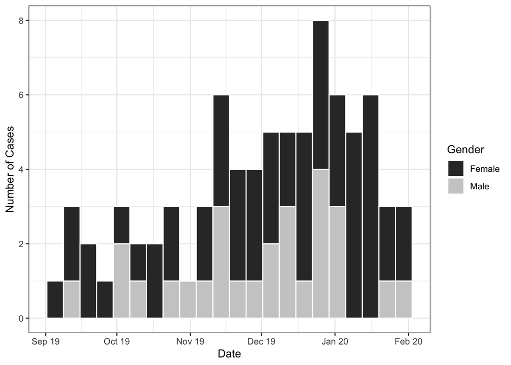

**Figure 2: Weekly incidence by case’s gender**

The vast majority of cases, overall, are female (n = 80, 72.1%). According to Figure 2, this pattern does not appear to change over the course of the epidemic.

| **Table 1:** **Case Fatality Ratios (CFR) by case definition and gender** Case Definition | **Table 1:** **Case Fatality Ratios (CFR) by case definition and gender** | **Table 1:** **Case Fatality Ratios (CFR) by case definition and gender** Cases Female | **Table 1:** **Case Fatality Ratios (CFR) by case definition and gender** Cases Male | **Table 1:** **Case Fatality Ratios (CFR) by case definition and gender** Cases Total | **Table 1:** **Case Fatality Ratios (CFR) by case definition and gender** | **Table 1:** **Case Fatality Ratios (CFR) by case definition and gender** Deaths Female | **Table 1:** **Case Fatality Ratios (CFR) by case definition and gender** Deaths Male | **Table 1:** **Case Fatality Ratios (CFR) by case definition and gender** Deaths Total | **Table 1:** **Case Fatality Ratios (CFR) by case definition and gender** | **Table 1:** **Case Fatality Ratios (CFR) by case definition and gender** Case Fatality Ratios (%) Female | **Table 1:** **Case Fatality Ratios (CFR) by case definition and gender** Case Fatality Ratios (%) Male | **Table 1:** **Case Fatality Ratios (CFR) by case definition and gender** Case Fatality Ratios (%) Total |
| --- | --- | --- | --- | --- | --- | --- | --- | --- | --- | --- | --- | --- |
| Confirmed |  | 51 | 21 | 72 |  | 32 | 13 | 45 |  | 62.7 | 61.9 | 62.5 |
| Probable |  | 26 | 9 | 35 |  | 26 | 9 | 35 |  | 100.0 | 100.0 | 100.0 |
| Suspected |  | 3 | 1 | 4 |  | 1 | 0 | 1 |  | 33.3 | 0.0 | 25.0 |

Overall, there were 81 (73 %) deaths in the population. Table 1 presents CFRs by case definition and gender. Cases that were classified as probable had the highest CRF, with 100% of cases dying. The CFR for confirmed cases was 62.5%, while the CFR for suspected cases was 25.0%. All suspected cases happened in the previous three weeks and thus they were probably still ill rather than fully recovered. The CFRs disagreggated by gender appear to be similar to the overall CFRs.

The time between when symptoms begin and when a case is reported might change as the outbreak progresses, which might be an indicator of community awareness. The trends over time in reporting delay are shown in Figure 3.

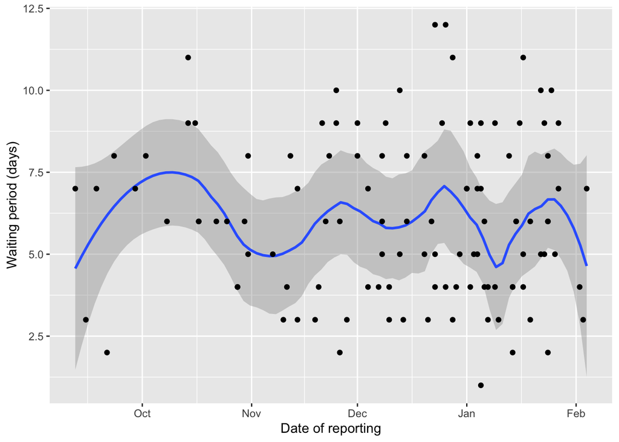

**Figure 3: Waiting time by date of reporting.** The waiting period for every case in the data is shown by the black dots. The blue curve shows the loess smoothed curve and the grey shedded regions show the error intervals.

The median waiting time in the data is 6(2, 11) days, while that estimated from the loess regression is 6.1(4.7, 7.3). The time it takes for a case to be reported given symptom onset does not seem to change much over the course of the outbreak thus far. However, the delay implies that the incidence curve drawn from reporting date has a time lag of about 6 days relative to the actual incidence. Any further interpretations of these data should bear this in mind.

There were 52 households represented in the data with a median size of 5 ( range: 1, 10). The proportion of the households that got infected was on average 0.367. In 48.1% of household introductions only a single member has so far been reported despite the occupancy of these households ranging from 1 to 8 members. The household incidence rate is defined as the number of secondary cases following a primary case per unit of person time during follow up. Here, the follow-up period for each secondary case is defined as the time from onset of the index case to onset of the secondary case.  
*Incidence rate = Total number of secondary cases / Total person time of follow-up*  
In the households that did have more than one case, the median incidence rate was 0.0408(0.0114,0.167)/person/day. This means that from the onset in the first household case, it would take approximately 24.5 (5.99,87.7) days for a new case to appear. Taken together, the average waiting time between symptom onset and reporting, and the time between onset in a primary household case and onset in a secondary case imply that contact tracing efforts immediately following cases reporting would be a timely intervention. 63.5% of primary household cases were Female.

We used the daily incidence curve obtained using all the reported onsets in the data, regardless of case definition to estimate the instataneous reproductive number, *R(t)*, which is a measure of infectivity of a single case in a population where some members have already been exposed to infection. *R(t)* can be used to asses is the epidemic is on the rise or declining, where values below 1 imply a decline. We used the EpiEstim package in R which uses a combination of incidence data and a serial interval distribution. We assumed that EVD has a mean serial interval of 15.3(SD: 9.3) days (WHO Ebola Response Team 2014).

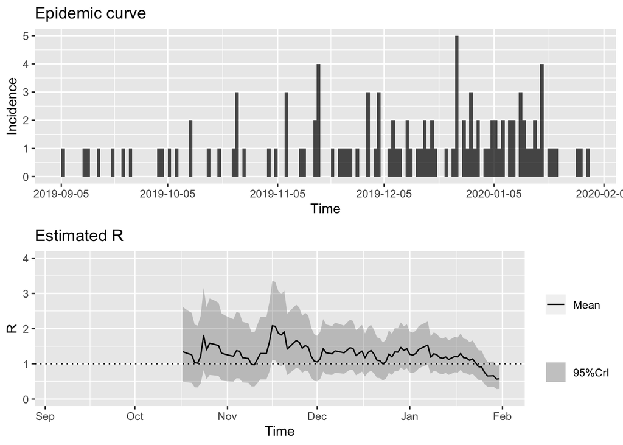

The reproductive number over time shown in the previous figure is consistently estimated to be above 1 up until the last 2 weeks. This dip in *R(t)* is reflecting the apparent dip in reported onsets. However, this should be interpreted with the reporting delays in mind, the last date of reported onsets is not reflective of the most recent infection events.

# **Actions to Date and Conclusions**

1. On the ground efforts to do contact tracing and diagnosis are successful since few cases are only “suspected”, and the incidence seems to be declining.
2. Still nearly three-quarters of cases are dying, so possibly treatment needs to be better managed?
3. There appears to be a significant incidenc of household infections implying the need to screen within households get vaccines to household members after first person infected.
4. Women seem to be particularly at risk of becoming infected (and hence introducing infections into the household), though not necessarily dying.

# **References**

WHO Ebola Response Team. 2014. “Ebola Virus Disease in West Africa — the First 9 Months of the Epidemic and Forward Projections” 371 (16). New England Journal of Medicine: 1481–95.